# Initialize Spirals by Special Data Types

Zuguang Gu (z.gu@dkfz.de)

2023-11-12

*This vignette is built with spiralize 1.0.6.*

## Work with date/time object

For time series data, values on *x*-axis are time points in a certain unit, e.g. days, or hours, and are linearly distributed along the axis. To map time series data to the spiral, internally a simple conversion is applied. Assume the first time point is `t1` and the last time point is `t2`, the number of time points is `n = t2 - t1` which is the time difference between the two. If we take `[0, 1]` for the first time point, `[1, 2]` for the second time point, and `[n-1, n]` for the last time point, then internally the spiral is initialized with `xlim = c(0, n)` and a time point `d` is converted to the internal numeric value by `d - d1 + 0.5`.

The unit of time point can be set via the argument `unit_on_axis` and the unit of the period can be set via the argument `period`, e.g. `unit_on_axis = "days"` and `period = "years"`. `unit_on_aixs` can be set as one of `"days"`, `"months"`, `"weeks"`, `"hours"`, `"mins"` and `"secs"`. And there are also corresponding values for `period`. If these two arguments are not set, they are guessed from `xlim` automatically.

In the following examples, also note the default value of `polar_lines_by` is also different for different `period`. E.g. there are 12 polar lines for years (12 months), 7 polar lines for weeks (7 weekdays), 24 polar lines for days (24 hours).

```r
spiral_initialize_by_time(xlim = c("2014-01-01", "2021-06-17"))
```

```
## 'unit_to_axis' is set to 'days'.
## 'period' is set to 'years'.
```

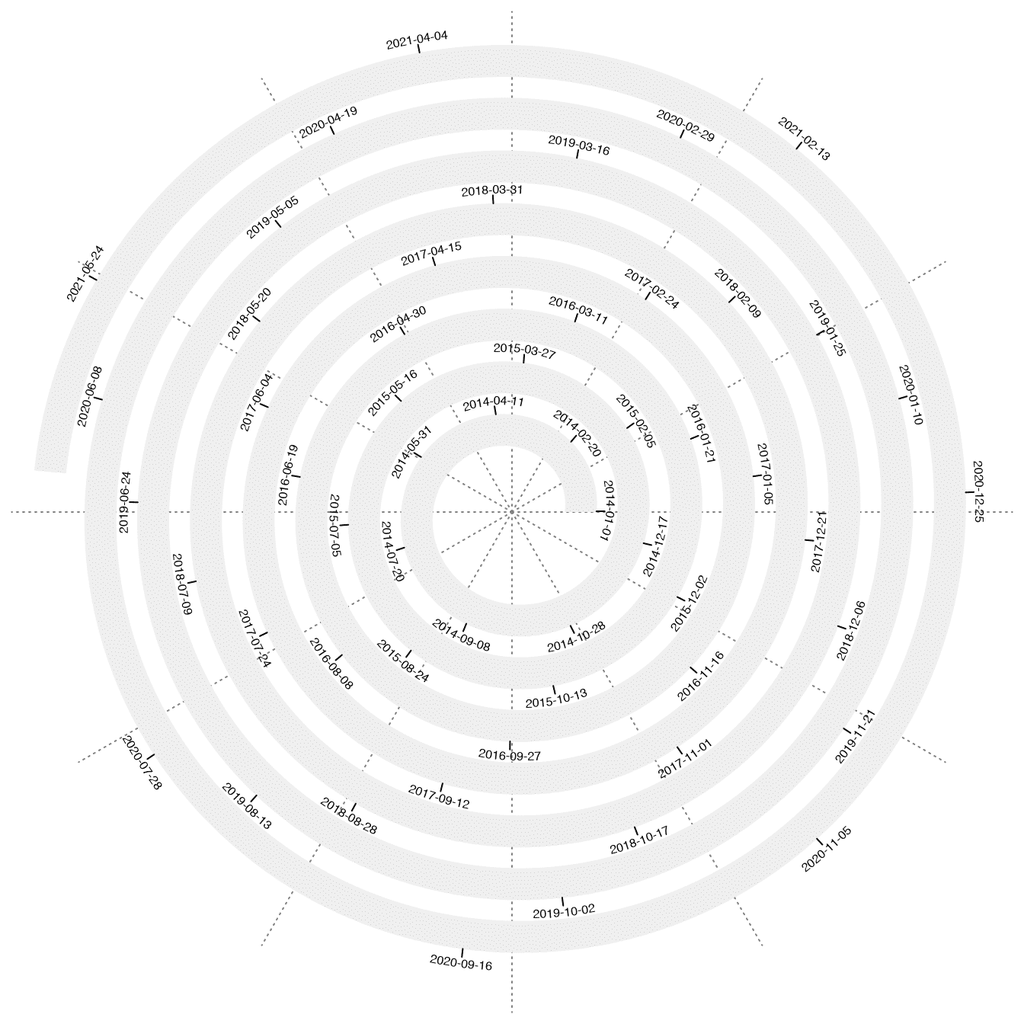

```r
spiral_track(height = 0.6)
spiral_axis()
```

```r
spiral_initialize_by_time(xlim = c("2021-01-01 00:00:00", "2021-01-05 00:00:00"))
```

```
## 'unit_to_axis' is set to 'mins'.
## 'period' is set to 'days'.
```

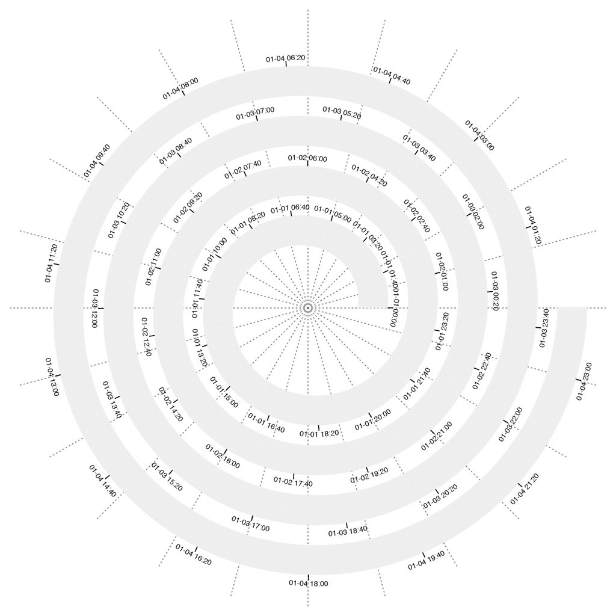

```r
spiral_track(height = 0.6)
spiral_axis()
```

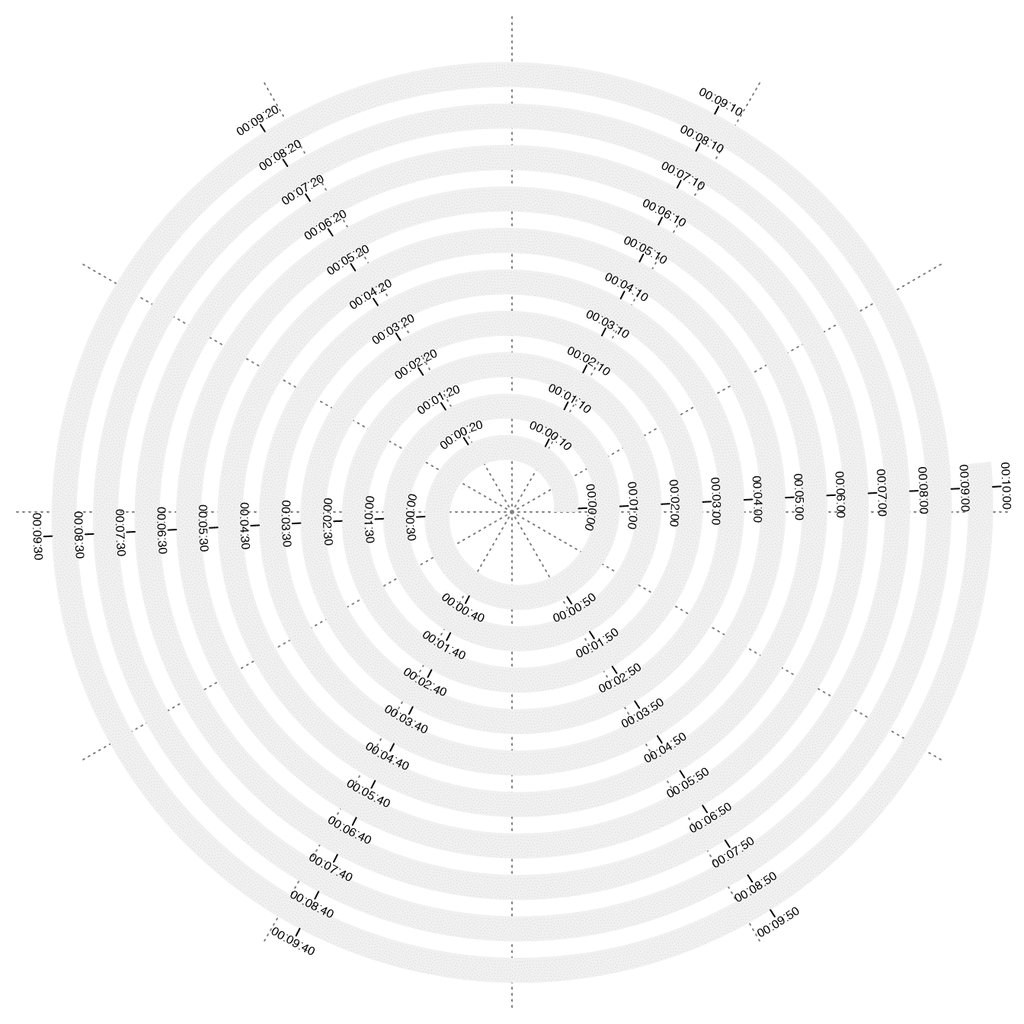

```r
spiral_initialize_by_time(xlim = c("2021-01-01 00:00:00", "2021-01-01 00:10:00"),
    unit_on_axis = "secs", period = "mins")
spiral_track(height = 0.6)
spiral_axis()
```

As shown in previous examples, the values for `xlim` should be a time/date object or their character forms that can be converted to the time/date object. Later when adding graphics, the time/date objects or their character forms can also be used as the *x*-locations for the low-level graphics functions. For example:

```r
spiral_points("2021-01-01", 0.5)
```

Argument `at` can be set to a vector of times to control the breaks on the axis. In the next example, I set the time interval to every two hours.

```r
spiral_initialize_by_time(xlim = c("2021-01-01 00:00:00", "2021-01-05 00:00:00"))
```

```
## 'unit_to_axis' is set to 'mins'.
## 'period' is set to 'days'.
```

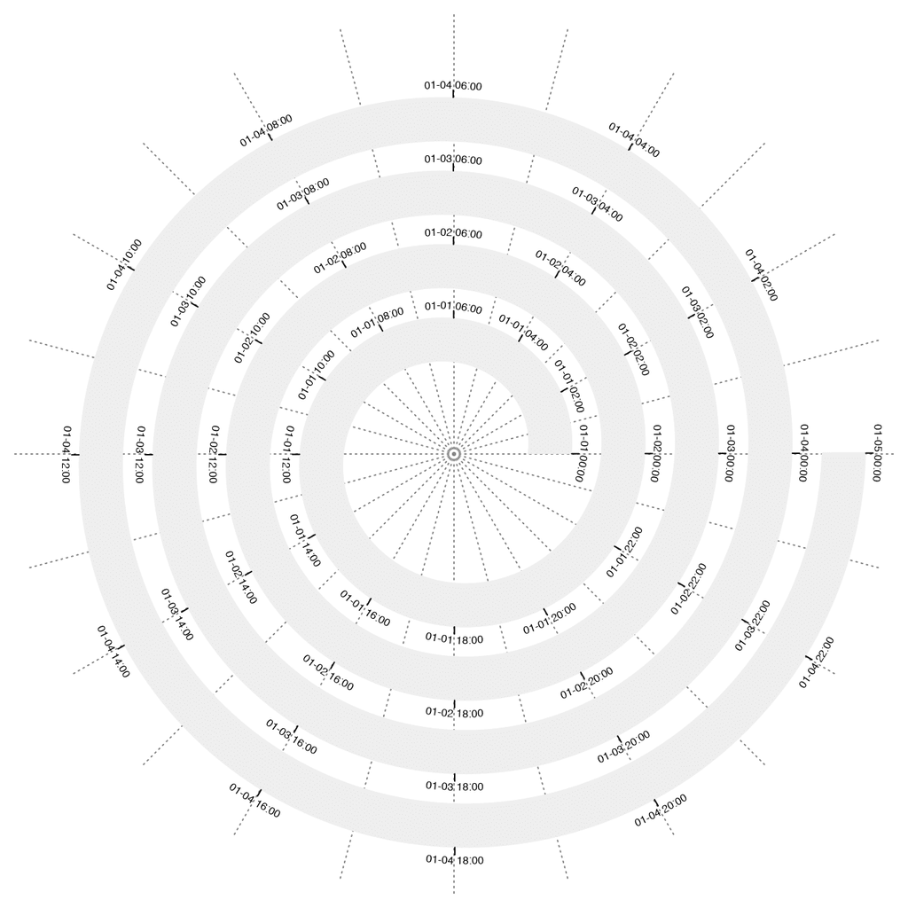

```r
spiral_track(height = 0.6)

library(lubridate)
# `by` is measured in seconds
at = seq(as.POSIXlt("2021-01-01 00:00:00"), as.POSIXlt("2021-01-05 00:00:00"), by = 2*60*60)
spiral_axis(at = at)
```

```r
spiral_initialize_by_time(xlim = c("2021-01-01 00:00:00", "2021-01-03 00:00:00"),
    start = 360 + 90, period_per_loop = 0.5, clockwise = TRUE)
```

```
## 'unit_to_axis' is set to 'mins'.
## 'period' is set to 'days'.
```

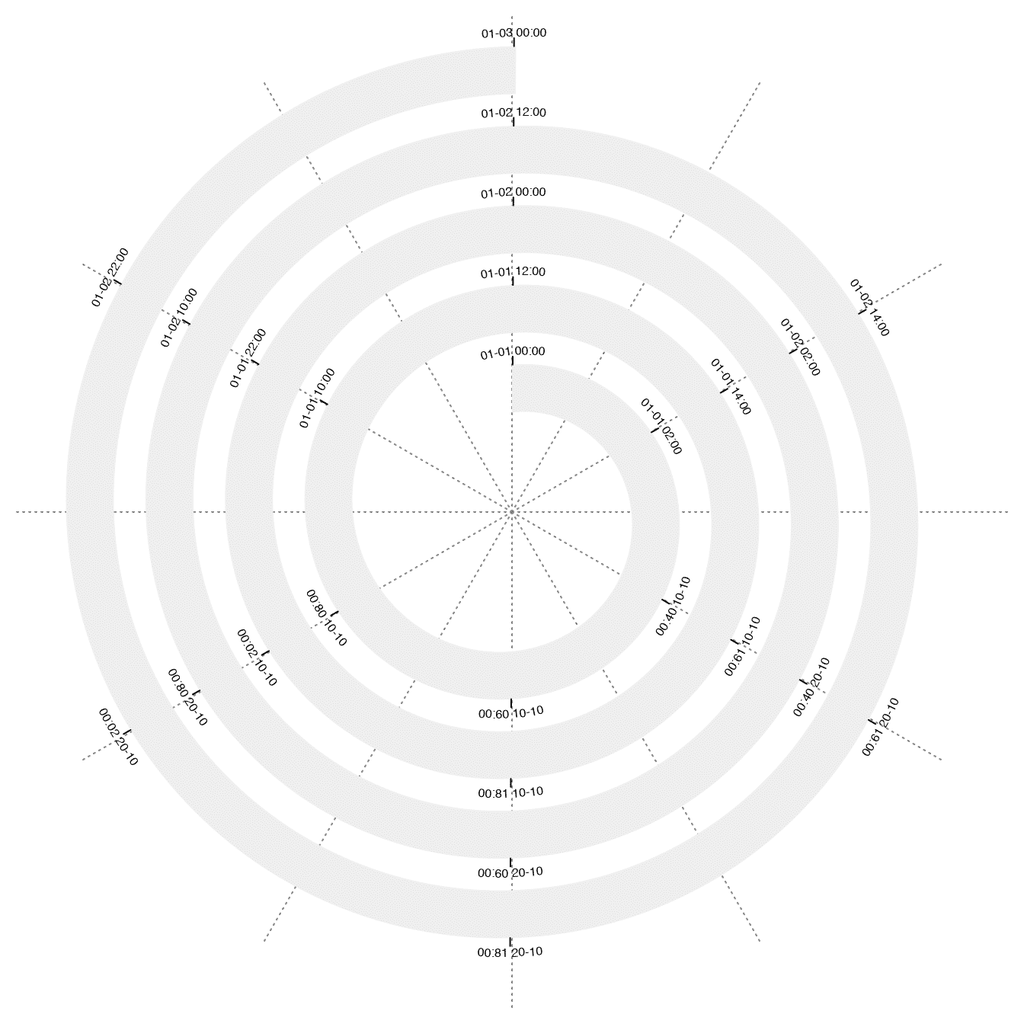

```r
spiral_track(height = 0.6)
at = seq(as.POSIXlt("2021-01-01 00:00:00"), as.POSIXlt("2021-01-05 00:00:00"), by = 2*60*60)
spiral_axis(at = at)
```

```
## 'unit_to_axis' is set to 'days'.
## 'period' is set to 'years'.
```

```
## 'unit_to_axis' is set to 'days'.
## 'period' is set to 'years'.
```

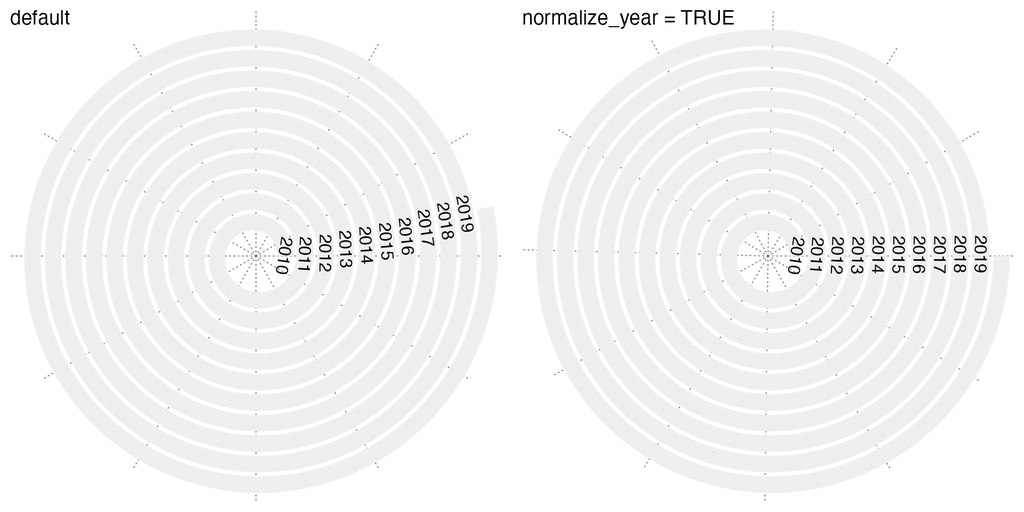

```r
# the left plot
spiral_initialize_by_time(xlim = c("2010-01-01", "2019-12-31"))
spiral_track()
for(i in 0:9) {
    # years() is from lubridate package
    spiral_text(as.POSIXlt("2010-01-01") + years(i), 0.5, 2010 + i, facing = "inside")
}

# the right plot
spiral_initialize_by_time(xlim = c("2010-01-01", "2019-12-31"),
    normalize_year = TRUE)
spiral_track()
for(i in 0:9) {
    spiral_text(as.POSIXlt("2010-01-01") + years(i), 0.5, 2010 + i, facing = "inside")
}
```

Last, when each loop corresponds to a year and units on axis are days, and when `normalize_year` is set to `TRUE`, the background sectors partitioned by dashed radical lines actually correspond to the proportion of month days in a year, i.e., the width of Feburary is the smallest.

```r
spiral_initialize_by_time(xlim = c("2010-01-01", "2014-12-31"), normalize_year = TRUE)
```

```
## 'unit_to_axis' is set to 'days'.
## 'period' is set to 'years'.
```

```r
spiral_track()
for(i in 0:11) {
    d = as.POSIXlt("2014-01-15") + months(i)
    spiral_text(d, 1.5, month.name[month(d)], gp = gpar(fontsize = 8),
        facing = "inside", nice_facing = TRUE)
}
```

[figure not shown]

## Work with genomic coordinates

Genomic data can be represented as a data frame (e.g. in *bed* format), or as a `GRanges` object. To initialize the spiral for genomic data visualization, the data on *x*-axis corresponds to the genomic coordinates. The spiral with genomic data can be initialized by the function `spiral_initialize_by_gcoor()`. The genomic coordinates are linear numeric values, thus, `spiral_initialize_by_gcoor()` is basically the same as `spiral_initialize()`. The only difference is the axis labels are automatically formatted for genomic coordinates.

Also since normally there are no periodic patterns for genomc data, `scale_by` is by default set to `"curve_length"`.

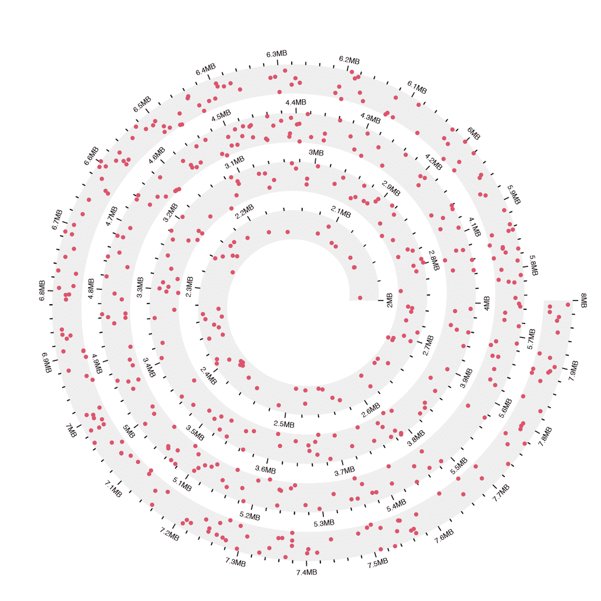

```r
spiral_initialize_by_gcoor(xlim = c(2e6, 8e6))  # 2MB to 8MB
spiral_track(height = 0.6)
spiral_axis()
spiral_points(x = runif(500, min = 2e6, max = 8e6), runif(500), pch = 16, gp = gpar(col = 2))
```